# README

Ryan^3 + John

2024-03-29

Group Name: **Ryan^3 + John**

Group Members:

- **Ryan Ledbetter**
- **Ryan Riebesehl**
- **Ryan Rockey**
- **John Nesnidal**

## English Premier League Statistics

Our data encompasses the last 22 years of the English Premier League, the largest soccer league in the world, by revenue. This includes statistics about every game, including goals scored, shots taken, the teams involved, even betting odds for many of the games.

```r
##prem <- read.csv(file.choose(), header = T)
prem <- read.csv("Datasets/final_dataset.csv")

head(prem, 3)
```

```
##   X     Date HomeTeam      AwayTeam FTHG FTAG FTR HTGS ATGS HTGC ATGC HTP ATP
## 1 0 19/08/00 Charlton      Man City    4    0   H    0    0    0    0   0   0
## 2 1 19/08/00  Chelsea      West Ham    4    2   H    0    0    0    0   0   0
## 3 2 19/08/00 Coventry Middlesbrough    1    3  NH    0    0    0    0   0   0
##   HM1 HM2 HM3 HM4 HM5 AM1 AM2 AM3 AM4 AM5 MW HTFormPtsStr ATFormPtsStr
## 1   M   M   M   M   M   M   M   M   M   M  1        MMMMM        MMMMM
## 2   M   M   M   M   M   M   M   M   M   M  1        MMMMM        MMMMM
## 3   M   M   M   M   M   M   M   M   M   M  1        MMMMM        MMMMM
##   HTFormPts ATFormPts HTWinStreak3 HTWinStreak5 HTLossStreak3 HTLossStreak5
## 1         0         0            0            0             0             0
## 2         0         0            0            0             0             0
## 3         0         0            0            0             0             0
##   ATWinStreak3 ATWinStreak5 ATLossStreak3 ATLossStreak5 HTGD ATGD DiffPts
## 1            0            0             0             0    0    0       0
## 2            0            0             0             0    0    0       0
## 3            0            0             0             0    0    0       0
##   DiffFormPts
## 1           0
## 2           0
## 3           0
```

```r
##Missing Values:
missing_values <- colSums(is.na(prem))
print(missing_values)
```

```
##             X          Date      HomeTeam      AwayTeam          FTHG
##             0             0             0             0             0
##          FTAG           FTR          HTGS          ATGS          HTGC
##             0             0             0             0             0
##          ATGC           HTP           ATP           HM1           HM2
##             0             0             0             0             0
##           HM3           HM4           HM5           AM1           AM2
##             0             0             0             0             0
##           AM3           AM4           AM5            MW  HTFormPtsStr
##             0             0             0             0             0
##  ATFormPtsStr     HTFormPts     ATFormPts  HTWinStreak3  HTWinStreak5
##             0             0             0             0             0
## HTLossStreak3 HTLossStreak5  ATWinStreak3  ATWinStreak5 ATLossStreak3
##             0             0             0             0             0
## ATLossStreak5          HTGD          ATGD       DiffPts   DiffFormPts
##             0             0             0             0             0
```

```r
##Date-time Format:
prem$Date <- as.Date(prem$Date, format = "%d/%m/%y")

##Unique Values:
unique_teams <- unique(c(prem$HomeTeam, prem$AwayTeam))
print(unique_teams)
```

```
##  [1] "Charlton"         "Chelsea"          "Coventry"         "Derby"
##  [5] "Leeds"            "Leicester"        "Liverpool"        "Sunderland"
##  [9] "Tottenham"        "Man United"       "Arsenal"          "Bradford"
## [13] "Ipswich"          "Middlesbrough"    "Everton"          "Man City"
## [17] "Newcastle"        "Southampton"      "West Ham"         "Aston Villa"
## [21] "Bolton"           "Blackburn"        "Fulham"           "Birmingham"
## [25] "Middlesboro"      "West Brom"        "Portsmouth"       "Wolves"
## [29] "Norwich"          "Crystal Palace"   "Wigan"            "Reading"
## [33] "Sheffield United" "Watford"          "Hull"             "Stoke"
## [37] "Burnley"          "Blackpool"        "QPR"              "Swansea"
## [41] "Cardiff"          "Bournemouth"      "Brighton"         "Huddersfield"
```

```r
## Possible Unnecessay Columns:
columns_to_remove <- c("Div", "Time", "Referee")
prem_clean <- prem[, !(names(prem) %in% columns_to_remove)]
```

## **Data Explanation:**

Our dataset consisted of many data points but these were not found across all of the csv files provided. The columns that were provided include: Our dataset has many fields, those include:

Div: (String) Representss the League Division  
Date: (Date) Match Date (dd/mm/yy)  
Time: (Time) Time of match (Military time)  
HomeTeam: (String) Home Team  
AwayTeam: (String) Away Team  
FTHG: (Int) Full Time Home Team Goals FTAG: (Int) Full Time Away Team Goals  
FTR: (H=Home Win, D=Draw, A=Away Win) Full Time Result  
HTHG: (Int) Half Time Home Team Goals  
HTAG: (Int) Half Time Away Team Goals  
HTR: (H=Home Win, D=Draw, A=Away Win) Half Time Result

and Match Statistics (where available)  
Attendance: (Int) Crowd Attendance  
Referee: (String) Match Referee  
HS: (Int) Home Team Shots  
AS: (Int) Away Team Shots  
HST: (Int) Home Team Shots on Target  
AST: (Int)Away Team Shots on Target  
HHW: (Int) Home Team Hit Woodwork  
AHW: (Int) Away Team Hit Woodwork  
HC: (Int) Home Team Corners  
AC: (Int) Away Team Corners  
HF: (Int) Home Team Fouls Committed  
AF: (Int) Away Team Fouls Committed  
HO: (Int) Home Team Offsides  
AO: (Int) Away Team Offsides  
HY: (Int) Home Team Yellow Cards  
AY: (Int) Away Team Yellow Cards  
HR: (Int) Home Team Red Cards  
AR: (Int) Away Team Red Cards HBP: (Int) Home Team Bookings Points (10 : yellow, 25 : red)  
ABP: (Int) Away Team Bookings Points (10 : yellow, 25 : red)

Additionally there were more betting odds representing multiple forms of betting such as

**Additional Columns**

```
  Key to 1X2 (match) betting odds data:
    B365H:
    (Float) Bet365 home win odds
    B365D:
    (Float) Bet365 draw odds
    B365A:
    (Float) Bet365 away win odds
    BSH:
    (Float) Blue Square home win odds
    BSD:
    (Float) Blue Square draw odds
    BSA:
    (Float) Blue Square away win odds
    BWH:
    (Float) Bet&Win home win odds
    BWD:
    (Float) Bet&Win draw odds
    BWA:
    (Float) Bet&Win away win odds
    GBH:
    (Float) Gamebookers home win odds
    GBD:
    (Float) Gamebookers draw odds
    GBA:
    (Float) Gamebookers away win odds
    IWH:
    (Float) Interwetten home win odds
    IWD:
    (Float) Interwetten draw odds
    IWA:
    (Float) Interwetten away win odds
    LBH:
    (Float) Ladbrokes home win odds
    LBD:
    (Float) Ladbrokes draw odds
    LBA:
    (Float) Ladbrokes away win odds
    PSH:
    (Float) Pinnacle Sports home win odds
    PSD:
    (Float) Pinnacle Sports draw odds
    PSA:
    (Float) Pinnacle Sports away win odds
    SOH:
    (Float) Sporting Odds home win odds
    SOD:
    (Float) Sporting Odds draw odds
    SOA:
    (Float) Sporting Odds away win odds
    SBH:
    (Float) Sportingbet home win odds
    SBD:
    (Float) Sportingbet draw odds
    SBA:
    (Float) Sportingbet away win odds
    SJH:
    (Float) Stan James home win odds
    SJD:
    (Float) Stan James draw odds
    SJA:
    (Float) Stan James away win odds
    SYH:
    (Float) Stanleybet home win odds
    SYD:
    (Float) Stanleybet draw odds
    SYA:
    (Float) Stanleybet away win odds
    VCH:
    (Float) VC Bet home win odds
    VCD:
    (Float) VC Bet draw odds
    VCA:
    (Float) VC Bet away win odds
    WHH:
    (Float) William Hill home win odds
    WHD:
    (Float) William Hill draw odds
    WHA:
    (Float) William Hill away win odds

    Bb1X2:
    (Float) Number of BetBrain bookmakers used to calculate match odds averages and maximums
    BbMxH:
    (Float) Betbrain maximum home win odds
    BbAvH:
    (Float) Betbrain average home win odds
    BbMxD:
    (Float) Betbrain maximum draw odds
    BbAvD:
    (Float) Betbrain average draw win odds
    BbMxA:
    (Float) Betbrain maximum away win odds
    BbAvA:
    (Float) Betbrain average away win odds



    Key to total goals betting odds:

    BbOU:
    (Float) Number of BetBrain bookmakers used to calculate over/under 2.5 goals (total goals) averages and maximums
    BbMx>2.5:
    (Float) Betbrain maximum over 2.5 goals
    BbAv>2.5:
    (Float) Betbrain average over 2.5 goals
    BbMx<2.5:
    (Float) Betbrain maximum under 2.5 goals
    BbAv<2.5:
    (Float) Betbrain average under 2.5 goals

    GB>2.5:
    (Float) Gamebookers over 2.5 goals
    GB<2.5:
    (Float) Gamebookers under 2.5 goals
    B365>2.5:
    (Float) Bet365 over 2.5 goals
    B365<2.5:
    (Float) Bet365 under 2.5 goals


    Key to Asian handicap betting odds:

    BbAH:
    (Float) Number of BetBrain bookmakers used to Asian handicap averages and maximums
    BbAHh:
    (Float) Betbrain size of handicap (home team)
    BbMxAHH:
    (Float) Betbrain maximum Asian handicap home team odds
    BbAvAHH:
    (Float) Betbrain average Asian handicap home team odds
    BbMxAHA:
    (Float) Betbrain maximum Asian handicap away team odds
    BbAvAHA:
    (Float) Betbrain average Asian handicap away team odds

    GBAHH:
    (Float) Gamebookers Asian handicap home team odds
    GBAHA:
    (Float) Gamebookers Asian handicap away team odds
    GBAH:
    (Float) Gamebookers size of handicap (home team)
    LBAHH:
    (Float) Ladbrokes Asian handicap home team odds
    LBAHA:
    (Float) Ladbrokes Asian handicap away team odds
    LBAH:
    (Float) Ladbrokes size of handicap (home team)
    B365AHH:
    (Float) Bet365 Asian handicap home team odds
    B365AHA:
    (Float) Bet365 Asian handicap away team odds
    B365AH:
    (Float) Bet365 size of handicap (home team)
```

## **Marginal Summaries:**

```r
##Summary Statistics:
summary(prem_clean)
```

```
##        X             Date              HomeTeam           AwayTeam
##  Min.   :   0   Min.   :2000-08-19   Length:6840        Length:6840
##  1st Qu.:1710   1st Qu.:2005-12-31   Class :character   Class :character
##  Median :3420   Median :2010-06-26   Mode  :character   Mode  :character
##  Mean   :3420   Mean   :2010-06-23
##  3rd Qu.:5129   3rd Qu.:2014-12-29
##  Max.   :6839   Max.   :2020-12-29
##       FTHG            FTAG          FTR                 HTGS
##  Min.   :0.000   Min.   :0.00   Length:6840        Min.   :  0.00
##  1st Qu.:1.000   1st Qu.:0.00   Class :character   1st Qu.: 11.00
##  Median :1.000   Median :1.00   Mode  :character   Median : 23.00
##  Mean   :1.527   Mean   :1.13                      Mean   : 24.42
##  3rd Qu.:2.000   3rd Qu.:2.00                      3rd Qu.: 35.00
##  Max.   :9.000   Max.   :7.00                      Max.   :102.00
##       ATGS             HTGC           ATGC            HTP
##  Min.   :  0.00   Min.   : 0.0   Min.   : 0.00   Min.   :0.0000
##  1st Qu.: 11.00   1st Qu.:11.0   1st Qu.:11.00   1st Qu.:0.8889
##  Median : 23.00   Median :23.0   Median :23.00   Median :1.1724
##  Mean   : 24.51   Mean   :24.5   Mean   :24.35   Mean   :1.2090
##  3rd Qu.: 35.00   3rd Qu.:36.0   3rd Qu.:36.00   3rd Qu.:1.5556
##  Max.   :105.00   Max.   :85.0   Max.   :82.00   Max.   :2.7368
##       ATP             HM1                HM2                HM3
##  Min.   :0.0000   Length:6840        Length:6840        Length:6840
##  1st Qu.:0.9062   Class :character   Class :character   Class :character
##  Median :1.1923   Mode  :character   Mode  :character   Mode  :character
##  Mean   :1.2268
##  3rd Qu.:1.5625
##  Max.   :2.7619
##      HM4                HM5                AM1                AM2
##  Length:6840        Length:6840        Length:6840        Length:6840
##  Class :character   Class :character   Class :character   Class :character
##  Mode  :character   Mode  :character   Mode  :character   Mode  :character
##
##
##
##      AM3                AM4                AM5                  MW
##  Length:6840        Length:6840        Length:6840        Min.   : 1.0
##  Class :character   Class :character   Class :character   1st Qu.:10.0
##  Mode  :character   Mode  :character   Mode  :character   Median :19.5
##                                                           Mean   :19.5
```

[output cut: 15 more lines]

```
##  Max.   :1.00000   Max.   :1.00000   Max.   :1.0000   Max.   :1.00000
##   ATWinStreak3      ATWinStreak5     ATLossStreak3     ATLossStreak5
##  Min.   :0.00000   Min.   :0.00000   Min.   :0.00000   Min.   :0.00000
##  1st Qu.:0.00000   1st Qu.:0.00000   1st Qu.:0.00000   1st Qu.:0.00000
##  Median :0.00000   Median :0.00000   Median :0.00000   Median :0.00000
##  Mean   :0.06287   Mean   :0.01652   Mean   :0.05102   Mean   :0.01023
##  3rd Qu.:0.00000   3rd Qu.:0.00000   3rd Qu.:0.00000   3rd Qu.:0.00000
##  Max.   :1.00000   Max.   :1.00000   Max.   :1.00000   Max.   :1.00000
##       HTGD               ATGD             DiffPts          DiffFormPts
##  Min.   :-3.00000   Min.   :-3.33333   Min.   :-2.36364   Min.   :-2.25000
##  1st Qu.:-0.50000   1st Qu.:-0.46429   1st Qu.:-0.45161   1st Qu.:-0.17647
##  Median :-0.07692   Median :-0.05000   Median : 0.00000   Median : 0.00000
##  Mean   :-0.00969   Mean   : 0.01454   Mean   :-0.01775   Mean   :-0.01809
##  3rd Qu.: 0.40000   3rd Qu.: 0.42105   3rd Qu.: 0.42857   3rd Qu.: 0.15385
##  Max.   : 4.00000   Max.   : 3.50000   Max.   : 2.28571   Max.   : 2.25000
```

```r
##Table of full time results:
outcome_freq <- table(prem_clean$FTR)
print(outcome_freq)
```

```
##
##    H   NH
## 3176 3664
```

### Questions to be answered:

#### General Trends over time: Ryan Riebesehl

- How has scoring changed over the years?
- How does scoring change across a full season?
- Is there a significant home advantage in the English Premier League over the past 22 years?

#### Home vs. Away performance: Ryan L

- How do teams tend to perform in home games vs. away games?
- Is there a measurable advantage to being at home?
- Is there a disadvantage to playing as the away team?

#### Goal scoring analysis:

- Which teams have scored the most/fewest goals?
- Does having a greater % of shots on target correlate to winning more?
- Is there a correlation between the number of shots taken by a team and the number of goals scored?

#### Betting trends:

- How well do the betting odds predict the outcome of a game?
- Is there a correlation between pre-match betting odds and match outcomes?

#### Predictive analysis:

- Can we use the previous data to predict the outcome of the rest of the current premier league season?
- How has the overall style of play (e.g., possession, based, counter-attacking) evolved over this 22-year period?

#### General Trends over time:

(1). How has Scoring Changed Over Time?

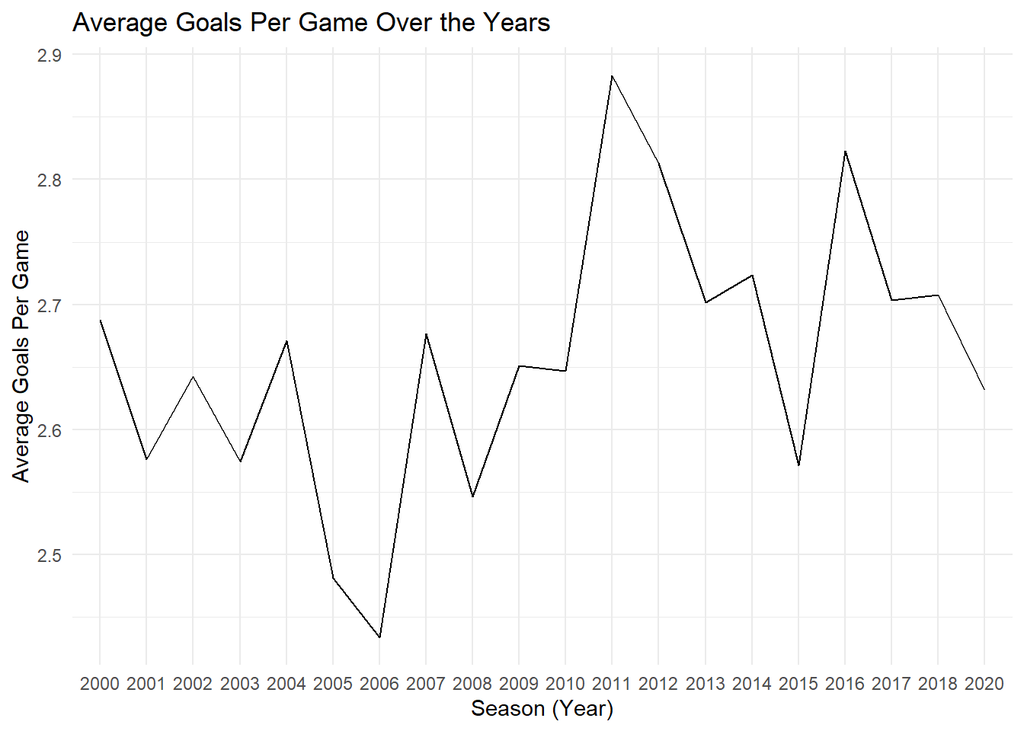

```r
library(dplyr)
library(ggplot2)
library(tidyverse)
#Add column for season (year):
prem_clean <- prem_clean %>%
  mutate(Season = format(Date, "%Y"))

#Average goals per game for each season:
avg_goals_per_season <- prem_clean %>%
  group_by(Season) %>%
  summarize(
    avg_goals = mean(FTHG + FTAG)  #(home goals + away goals)
  )

# Line Graph of the average goals per season:
ggplot(avg_goals_per_season, aes(x = Season, y = avg_goals, group = 1)) +
  geom_line() +
  labs(title = "Average Goals Per Game Over the Years",
       x = "Season (Year)",
       y = "Average Goals Per Game") +
  theme_minimal()
```

*Based on our line graph, the average goals per game were lower near the older years (2000-2009). While the average goals per game were higher in the more recent years (2010-2020). One reason why the average goals are increasing over the years could be due to multiple thrashings occurring between some teams and the rest of the league. Another reason could be that Premier League fans like a high goals-per-game ratio. Or from a strategic standpoint, there is a lack of defensive organisation.

*Resource:https://theathletic.com/5292045/2024/02/24/why-so-many-goals-premier-league/

-

(2). How does scoring change across a full season?

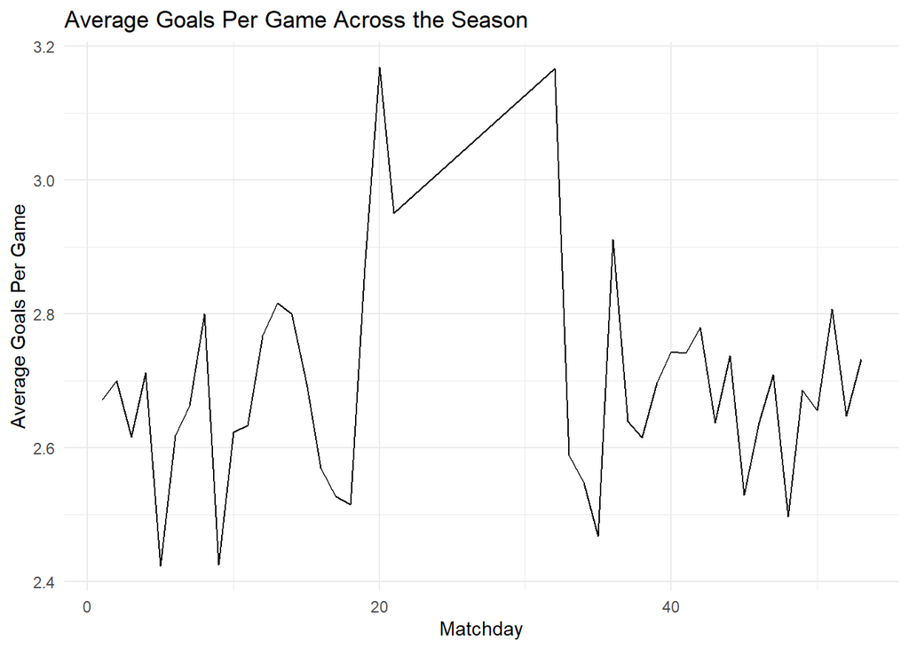

```r
#Column for matchday:
prem_clean <- prem_clean %>%
  mutate(Matchday = as.integer(format(Date, "%j")) %/% 7 + 1)

#Average goals per game for each matchday:
avg_goals_per_matchday <- prem_clean %>%
  group_by(Matchday) %>%
  summarize(
    avg_goals = mean(FTHG + FTAG)  #(home goals + away goals)
  )

#Line graph of average goals per matchday:
ggplot(avg_goals_per_matchday, aes(x = Matchday, y = avg_goals, group = 1)) +
  geom_line() +
  labs(title = "Average Goals Per Game Across the Season",
       x = "Matchday",
       y = "Average Goals Per Game") +
  theme_minimal()
```

*Resource:https://theanalyst.com/na/2023/12/goals-galore-how-the-premier-league-is-producing-more-goals-than-ever-before/

-

(3). Is there a significant home advantage in the English Premier League over the past 22 years?

```r
#Precentages of home wins and away wins:
home_advantage <- prem_clean %>%
  group_by(Season) %>%
  summarize(
    home_win_percentage = mean(FTR == "H") * 100,
    away_win_percentage = mean(FTR == "NH") * 100,
  )
print(home_advantage)
```

```
## # A tibble: 20 × 3
##    Season home_win_percentage away_win_percentage
##    <chr>                <dbl>               <dbl>
##  1 2000                  50.7                49.3
##  2 2001                  42.6                57.4
##  3 2002                  47.3                52.7
##  4 2003                  43.1                56.9
##  5 2004                  43.6                56.4
##  6 2005                  48.4                51.6
##  7 2006                  52.0                48.0
##  8 2007                  45.6                54.4
##  9 2008                  43.8                56.2
## 10 2009                  50.3                49.7
## 11 2010                  47.1                52.9
## 12 2011                  45.6                54.4
## 13 2012                  46.3                53.7
## 14 2013                  44.6                55.4
## 15 2014                  46.1                53.9
## 16 2015                  42.9                57.1
## 17 2016                  46.3                53.7
## 18 2017                  46.9                53.1
## 19 2018                  47.4                52.6
## 20 2020                  49.2                50.8
```

```r
#Chi-Square Test of Independe (Are these variables ralted?):
contingency_table <- table(prem_clean$FTR)
chi_square_test <- chisq.test(contingency_table)

print(chi_square_test)
```

```
##
##  Chi-squared test for given probabilities
##
## data:  contingency_table
## X-squared = 34.816, df = 1, p-value = 3.623e-09
```

```r
#T-test compaing average goals scored by home and away teams (Is there a difference in the means between the variables?):
t_test <- t.test(prem_clean$FTHG, prem_clean$FTAG)

print(t_test)
```

```
##
##  Welch Two Sample t-test
##
## data:  prem_clean$FTHG and prem_clean$FTAG
## t = 19.13, df = 13406, p-value < 2.2e-16
## alternative hypothesis: true difference in means is not equal to 0
## 95 percent confidence interval:
##  0.3565204 0.4379240
## sample estimates:
## mean of x mean of y
##  1.527485  1.130263
```

[figure not shown]

```r
#Line Graph Comparing home and away precentages over the years:
ggplot(home_advantage, aes(x = Season)) +
  geom_line(aes(y = home_win_percentage, color = "Home Wins", group = 1)) +
  geom_line(aes(y = away_win_percentage, color = "Away Wins", group = 2)) +
  labs(title = "Home/Away Advantage in the EPL Over the Past 22 Years",
       x = "Season (Year)",
       y = "Percentage") +
  scale_color_manual(values = c("Home Wins" = "blue", "Away Wins" = "red")) +
  theme_minimal() +
  theme(axis.text.x = element_text(angle = 45, hjust = 1))
```

*Resource: https://www.skysports.com/football/news/11661/12079338/premier-league-goals-and-away-wins-at-record-highs-has-home-advantage-been-wiped-out

#### Home vs. Away performance:

```r
# List of CSV files
file_list <- c("Datasets/2000-01.csv",
"Datasets/2001-02.csv",
"Datasets/2002-03.csv",
"Datasets/2003-04.csv",
"Datasets/2004-05.csv",
"Datasets/2005-06.csv",
"Datasets/2006-07.csv",
"Datasets/2007-08.csv",
"Datasets/2008-09.csv",
"Datasets/2009-10.csv",
"Datasets/2010-11.csv",
"Datasets/2011-12.csv",
"Datasets/2012-13.csv",
"Datasets/2013-14.csv",
"Datasets/2014-15.csv",
"Datasets/2015-16.csv",
"Datasets/2016-17.csv",
"Datasets/2017-18.csv",
"Datasets/2018-19.csv",
"Datasets/2019-20.csv",
"Datasets/2020-2021.csv",
"Datasets/2021-2022.csv")

# Read CSV files into a list of data frames
data_frames <- lapply(file_list, read.csv)

# Identify common columns
common_columns <- Reduce(intersect, lapply(data_frames, colnames))

# Subset data frames to keep only common columns
data_frames_subset <- lapply(data_frames, function(df) df[, common_columns])

# Merge data frames by rows
merged_data <- do.call(rbind, data_frames_subset)

# Write merged data frame to CSV
write.csv(merged_data, "merged_file.csv", row.names = FALSE)
```

1. How do teams tend to perform in home games vs. away games?

```r
avg_home_final_score <- mean(merged_data$FTHG)
avg_away_final_score <- mean(merged_data$FTAG)
avg_home_shots <- mean(merged_data$HST)
avg_away_shots <- mean(merged_data$AST)
avg_home_corners <- mean(merged_data$HC)
avg_away_corners <- mean(merged_data$AC)

final_score_percent = avg_home_final_score/avg_away_final_score
shots_percent = avg_home_shots/avg_away_shots
corners_percent = avg_home_corners/avg_away_corners

cat("The average final score per game by the home team is: ", avg_home_final_score, "\n")
```

```
## The average final score per game by the home team is:  1.516958
```

```r
cat("The average final score per game by the away team is: ", avg_away_final_score, "\n")
```

```
## The average final score per game by the away team is:  1.156234
```

```r
cat("The average shots on goal by the home team is: ", avg_home_shots, "\n")
```

```
## The average shots on goal by the home team is:  6.166085
```

```r
cat("The average shots on goal by the away team is: ", avg_away_shots, "\n")
```

```
## The average shots on goal by the away team is:  4.807232
```

```r
cat("The average amount of corner kicks by the home team is: ", avg_home_corners, "\n")
```

```
## The average amount of corner kicks by the home team is:  6.097756
```

```r
cat("The average amount of corner kicks by the away team is: ", avg_away_corners, "\n\n")
```

```
## The average amount of corner kicks by the away team is:  4.78803
```

```r
cat("The home team scores ", final_score_percent, " times more points.\n")
```

```
## The home team scores  1.311981  times more points.
```

```r
cat("The home team shoots on goal ", shots_percent, " times more.\n")
```

```
## The home team shoots on goal  1.282668  times more.
```

```r
cat("The home team gets ", corners_percent, " times more corner kicks.\n")
```

```
## The home team gets  1.273542  times more corner kicks.
```

2. Is there a measurable advantage to being at home?

```
## Defaulting to continuous.
```

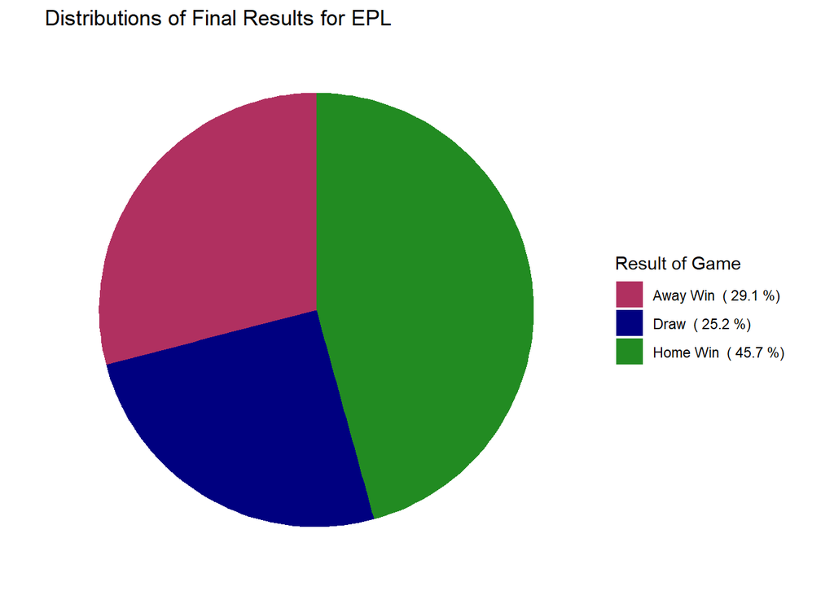

```r
home_wins <- table(merged_data$FTR == "H")
home_wins <- as.data.frame(home_wins)[["Freq"]][2]

away_wins <- table(merged_data$FTR == "A")
away_wins <- as.data.frame(away_wins)[["Freq"]][2]

draws <- table(merged_data$FTR == "D")
draws <- as.data.frame(draws)[["Freq"]][2]

FTR_counts = table(merged_data$FTR)
percentages <- round(prop.table(FTR_counts) * 100, 1)

pie_chart <- ggplot(data = NULL, aes(x = "", y = FTR_counts, fill = names(FTR_counts))) +
  geom_bar(stat = "identity") +
  coord_polar("y", start=0) +
  labs(title = "Distributions of Final Results for EPL", fill = "Result of Game") +
  theme_minimal() +
  theme(legend.position = "right", axis.text = element_blank(),
        axis.ticks = element_blank(),
        panel.grid  = element_blank(),
        axis.title = element_blank()) +
   scale_fill_manual(values = c("H" = "forestgreen", "A" = "maroon", "D" = "navy"),
                    labels = c(paste("Away Win", " (", percentages["A"], "%)"),
                               paste("Draw", " (", percentages["D"], "%)"),
                               paste("Home Win", " (", percentages["H"], "%)")))

# Display the pie chart
print(pie_chart)
```

```r
cat("In our data set, of the 8020 matches,", home_wins, "were won by the home team, while ", away_wins, "matches were won by the away team. The amount of matches that ended in a draw was", draws, ".\n")
```

```
## In our data set, of the 8020 matches, 3667 were won by the home team, while  2331 matches were won by the away team. The amount of matches that ended in a draw was 2022 .
```

By looking at the data from our past two questions, it does appear that there is an advantage to being the home team. By playing at your own field, you seem to take more shots on goal, get more opportunities for corner kicks, and overall win more matches. This could all be due to a high amount of experience and practice on that field as well as having a crowd that is likely biased towards the home team. Competeing is a mental activity as well as physical so having a crowd there to keep you going could make up a part of the difference. We have seen that there is an advantage to being the team who gets to play at their own field, but could there also be a disadvantage to being the team that is away? We wanted to look at how likely you are to get called for a foul.

3. Are teams more likely to get carded when away?

```r
avg_home_yellow <- mean(merged_data$HY)
avg_away_yellow <- mean(merged_data$AY)
avg_home_red <- mean(merged_data$HR)
avg_away_red <- mean(merged_data$AR)

avg_home_cards = avg_home_yellow + avg_home_red
avg_away_cards = avg_away_yellow + avg_away_red
card_percent = avg_away_cards/avg_home_cards

cat("The average amounts of cards per game recevied by the home team is: ", avg_home_cards, "\n")
```

```
## The average amounts of cards per game recevied by the home team is:  1.477556
```

```r
cat("The average amounts of cards per game recevied by the away team is: ", avg_away_cards, "\n")
```

```
## The average amounts of cards per game recevied by the away team is:  1.839651
```

```r
cat("The away team is ", card_percent, " times more likely to receive a card.")
```

```
## The away team is  1.245063  times more likely to receive a card.
```

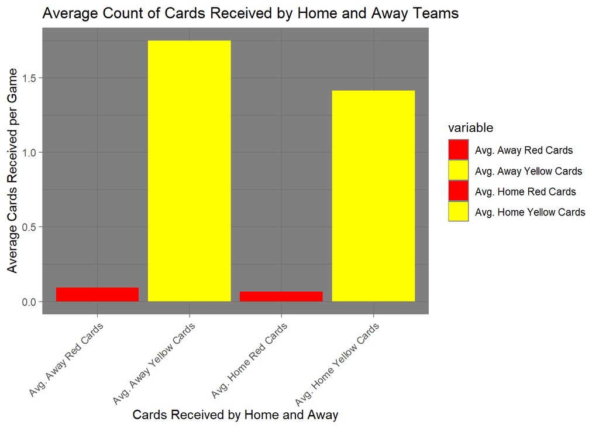

```r
data <- data.frame(
  variable = c("Avg. Home Yellow Cards", "Avg. Away Yellow Cards", "Avg. Home Red Cards", "Avg. Away Red Cards"),
  average = c(avg_home_yellow, avg_away_yellow, avg_home_red, avg_away_red)
)

ggplot(data, aes(x = variable, y = average, fill = variable)) +
  geom_bar(stat = "identity") +
  labs(title = "Average Count of Cards Received by Home and Away Teams",
       x = "Cards Received by Home and Away",
       y = "Average Cards Received per Game") +
  scale_fill_manual(values = c("Avg. Home Yellow Cards" = "yellow",
                                "Avg. Away Yellow Cards" = "yellow",
                                "Avg. Home Red Cards" = "red",
                                "Avg. Away Red Cards" = "red")) +
  theme_dark() +  theme(axis.text.x = element_text(angle = 45, hjust = 1))
```

Like all sports, in soccer there are penalties. If a player commits a foul, they will receive a yellow or red card. This is from the discretion of the referee at the game. This brought up the idea that playing an away game may bias how often teams get carded. From our data we found that by being the away team, you are approximately 1.25 times more likely to receive a card. This could be due to bias but could also be explained for reasons such as a team playing more aggressively when they are away or teams not wanting to be fouled out at a home game.

#### Goal Scoring Analysis:

- Which teams have scored the most/fewest goals?

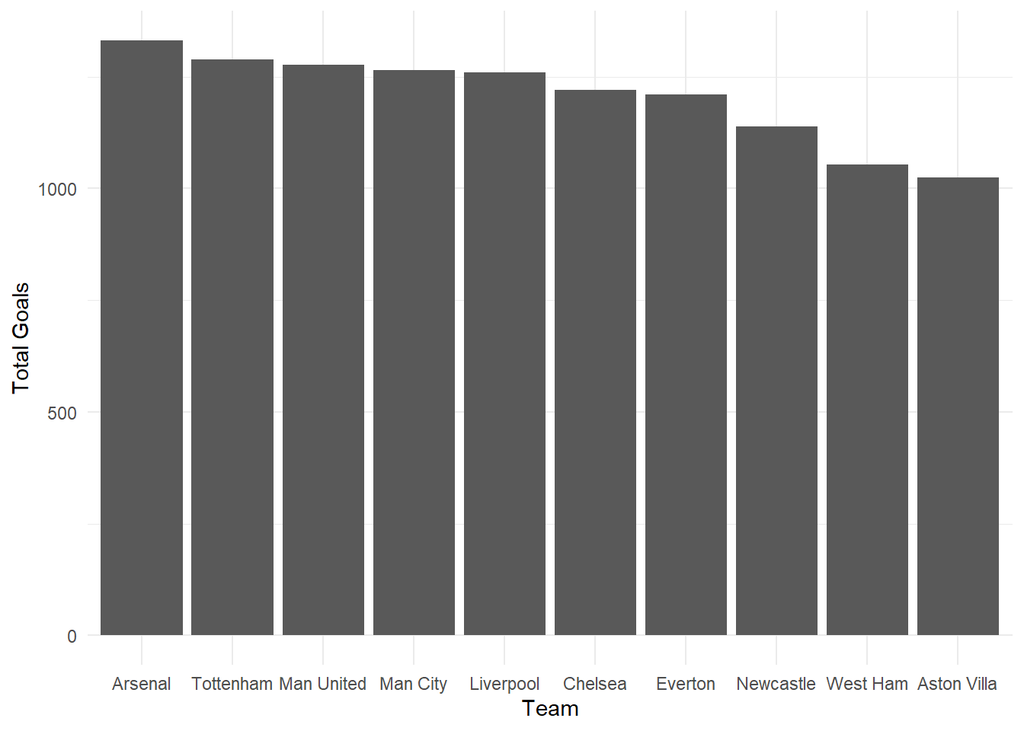

```r
# Get unique teams from both HomeTeam and AwayTeam columns
unique_teams <- unique(c(merged_data$HomeTeam, merged_data$AwayTeam))

# Initialize empty vectors to store the total home and away goals
home_goals <- numeric(length(unique_teams))
away_goals <- numeric(length(unique_teams))

# Loop through each unique team
for (i in 1:length(unique_teams)) {
  team <- unique_teams[i]
  home_goals[i] <- sum(merged_data$FTHG[merged_data$HomeTeam == team])
  away_goals[i] <- sum(merged_data$FTHG[merged_data$AwayTeam == team])
}

# Create dataframe with team names and total goals
goals_scored_by_team <- data.frame(
  team = unique_teams,
  home_goals = home_goals,
  away_goals = away_goals
)

# Create total_goals column
goals_scored_by_team$total_goals = goals_scored_by_team$home_goals + goals_scored_by_team$away_goals

# Create most goals dataframe
most_goals_scored_by_team <- goals_scored_by_team %>%
  arrange(desc(total_goals)) %>%
  slice_head(n = 10)

# Create fewest goals dataframe
fewest_goals_scored_by_team <- goals_scored_by_team %>%
  arrange(total_goals) %>%
  slice_head(n = 10)

# Create plot of the most goals and fewest goals
ggplot(most_goals_scored_by_team, aes(x = reorder(team, -total_goals), y = total_goals)) + geom_bar(stat = "identity") +
  labs(x="Team", y="Total Goals") + theme_minimal()
```

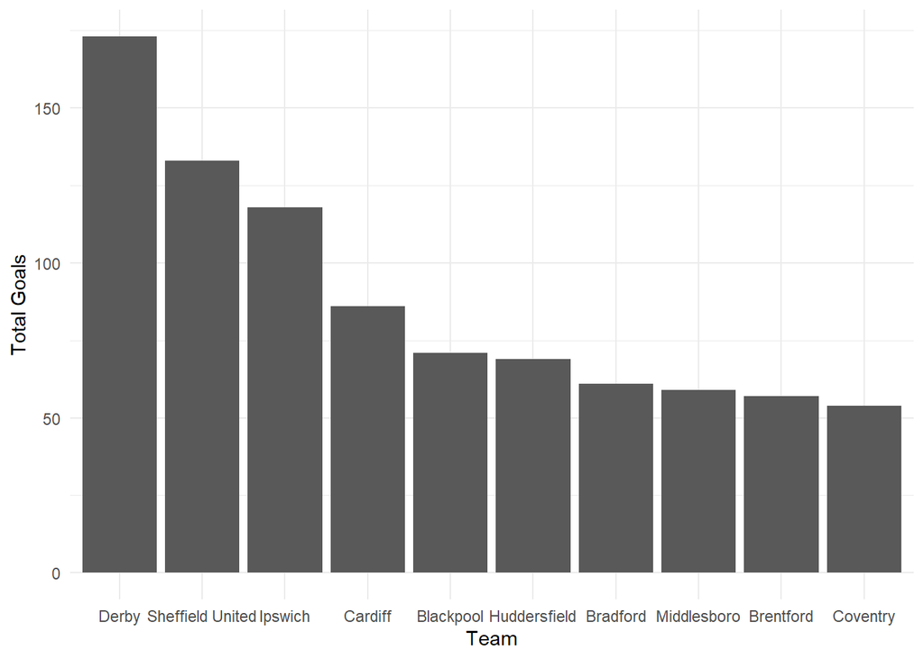

```r
ggplot(fewest_goals_scored_by_team, aes(x = reorder(team, -total_goals), y = total_goals)) + geom_bar(stat = "identity") +
  labs(x="Team", y="Total Goals") + theme_minimal()
```

- Does having a greater % of shots on target correlate to winning more?

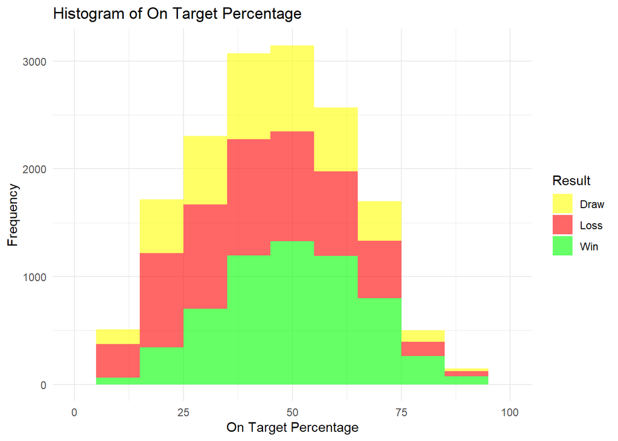

```r
library(ggplot2)
library(dplyr)

# Calculate on-target percentage for home and away teams
merged_data2 <- merged_data %>%
  mutate(HomeOnTargetPercent = (HST / HS) * 100,
         AwayOnTargetPercent = (AST / AS) * 100,
         HomeResult = ifelse(FTR == "H", "Win", ifelse(FTR == "A", "Loss", "Draw")),
         AwayResult = ifelse(FTR == "A", "Win", ifelse(FTR == "H", "Loss", "Draw")))

# Combine on-target percentage data for both home and away teams
on_target_data <- rbind(
  data.frame(OnTargetPercent = merged_data2$HomeOnTargetPercent, Result = merged_data2$HomeResult),
  data.frame(OnTargetPercent = merged_data2$AwayOnTargetPercent, Result = merged_data2$AwayResult)
)

# Plot histogram with combined data
ggplot(on_target_data, aes(x = OnTargetPercent, fill = Result)) +
  geom_histogram(bins = 10, binwidth = 10, position = "stack", alpha = 0.6) +
  scale_fill_manual(values = c("yellow", "red", "green")) +  # Specify colors for wins and losses
  labs(x = "On Target Percentage", y = "Frequency", title = "Histogram of On Target Percentage") + xlim(0,100) +
  theme_minimal()
```

- Is there a correlation between the number of shots taken by a team and the number of goals scored?

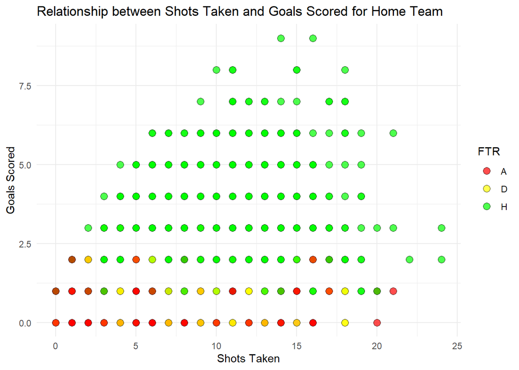

```r
# Plot shots taken
ggplot(merged_data2, aes(x = HST, y = FTHG, fill = FTR)) +
  geom_point(shape = 21, size = 3, alpha = 0.7) +
  scale_fill_manual(values = c("red", "yellow", "green")) +
  labs(x = "Shots Taken", y = "Goals Scored", title = "Relationship between Shots Taken and Goals Scored for Home Team") +
  theme_minimal()
```

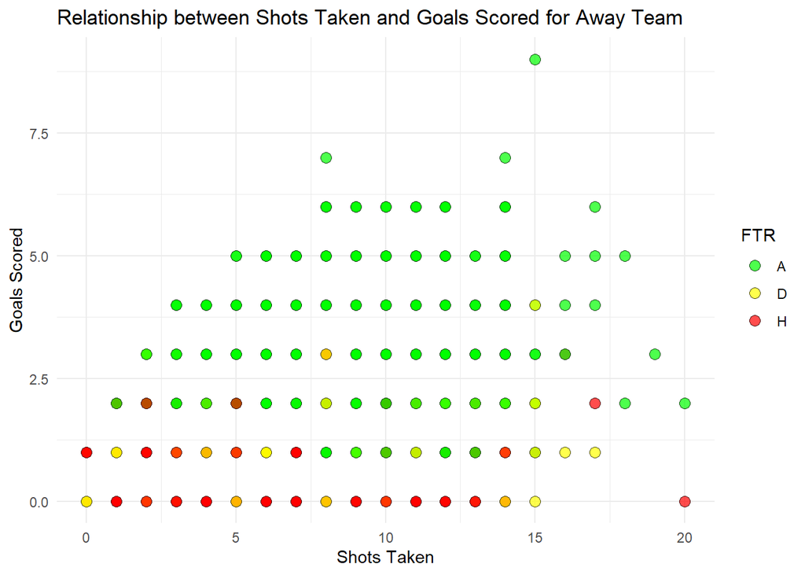

```r
# Plot scatter plot with different colors for result
ggplot(merged_data2, aes(x = AST, y = FTAG, fill = FTR)) +
  geom_point(shape = 21, size = 3, alpha = 0.7) +
  scale_fill_manual(values = c("green", "yellow", "red")) +
  labs(x = "Shots Taken", y = "Goals Scored", title = "Relationship between Shots Taken and Goals Scored for Away Team") +
  theme_minimal()
```